# Executive Summary

Robert Davis DeRodes, Josh Feldman, Zach Bogart, Ramy Jaber

4/26/2018

Our project involved scraping sighting reports from nuforc.org, the website of the National UFO Reporting Center. The National UFO Reporting Center was founded in 1974 in Seattle Washington, where it took in UFO sighting reports through phone calls. The NUFORC would grow and develop a website in October of 1998 and create an intake webpage for sighting reports, while also moving it’s headquarters to Davenport, Oregon.

While our goal of the project was to identify patterns in UFO sightings to possibly provide evidence of certain types of UFOs, our conclusions were mostly centered around the NUFORC and the underlying reasons as to why someone would see a UFO in the first place. For example, all of the background information about the NUFORC mentioned above was deduced solely from the data and then later confirmed by talking to the organization’s director.

We can clearly see that there is a large proliferation in sightings from November of 1998, almost certainly due to the addition of the website to the NUFORC’s intake tools.

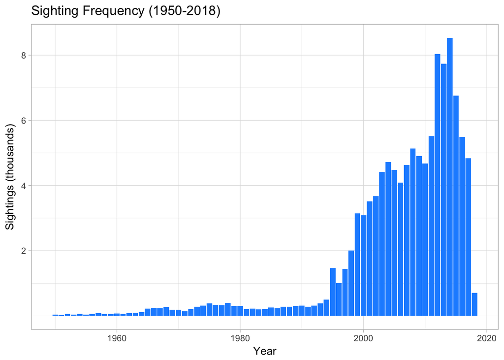

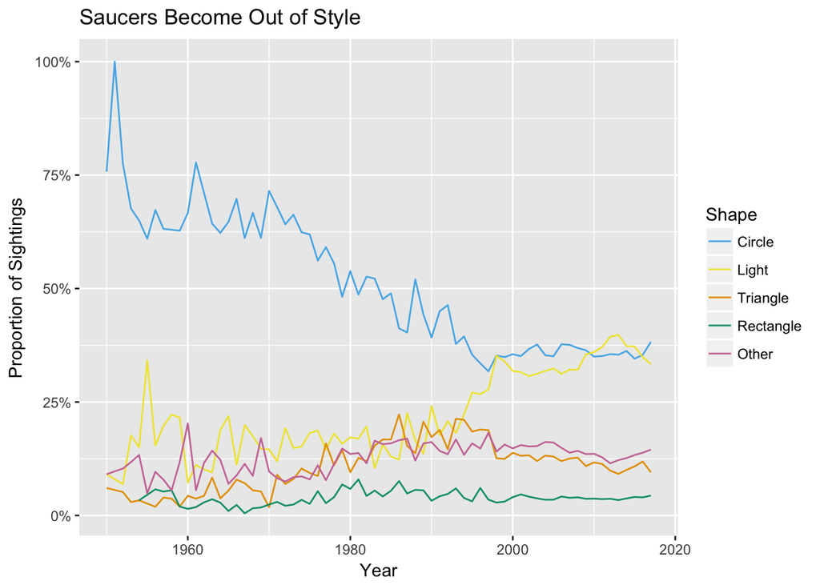

The graph below shows a fairly obvious finding that light oriented objects tend to be appear more frequently at night, while circles tend to be occur more during the day, especially compared to light. Overal, all objects are more frequent during the night time.

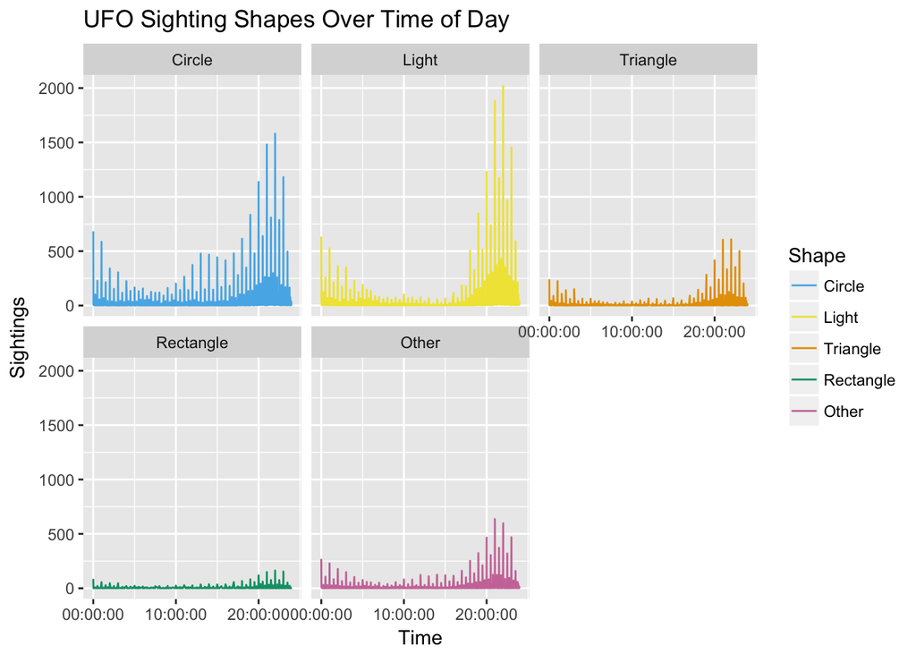

Another question of intrigue for our project was whether or not sighitngs occur in different areas of the United States. Given the folklore of UFOs, we were expecting UFOs to be most common in midwestern states with corn fields or Arizona and New Mexico - the fabled location of Area 51. While there might be some support for alien interest in the southwest United States, the states with the largest amount of sightings per 10,000 residents were Vermont, Washington, Montana, Alaska, Maine, and Oregon. Washington and Oregon make complete sense as those were the states the NUFORC was headquarted in when it did not have an online presence and did most of it’s marketing locally. The peculiar states that are so popular are Alaska, Vermont, and Maine as they are not local to the Pacific Northwest. This leads us to believe that one of the largest driving factors for the location of UFO sightings is how much time do the people in those states spend outside. Also, another factor is that these more northern states have significantly less daylight and as previously stated sightings are more likely to happen at later hours in the dark.

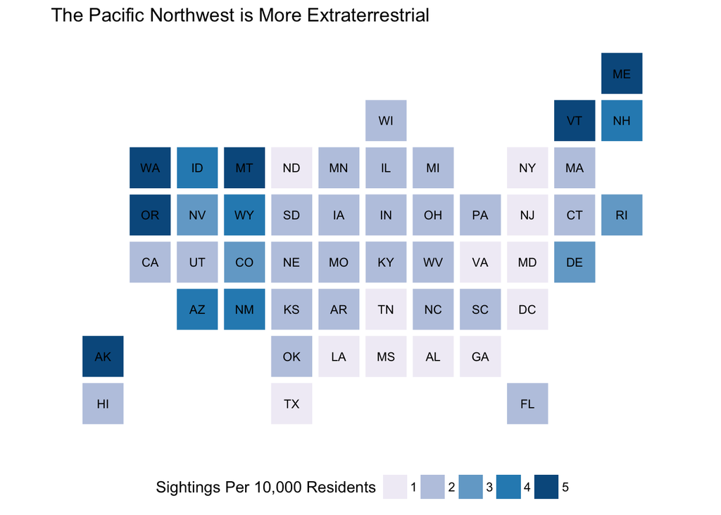

Confirming this assumption, the graph below clearly shows that UFO sightings are most popular in summer months, when people are outside most frequently.

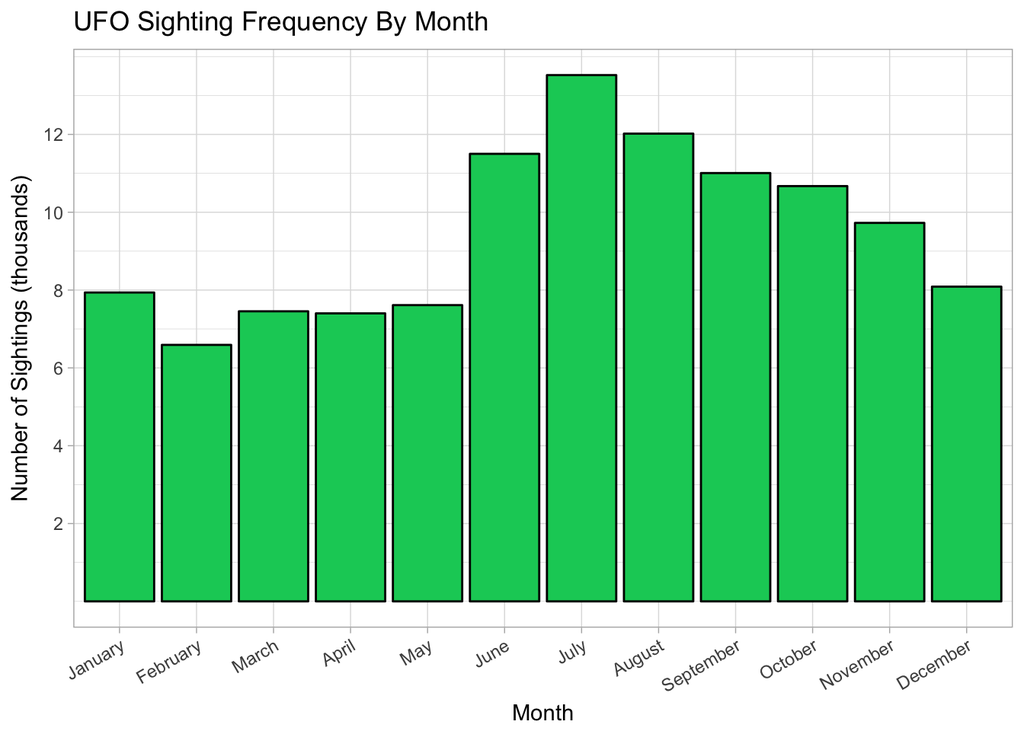

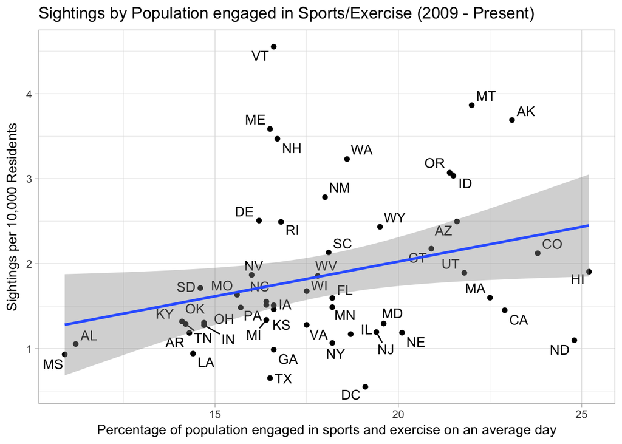

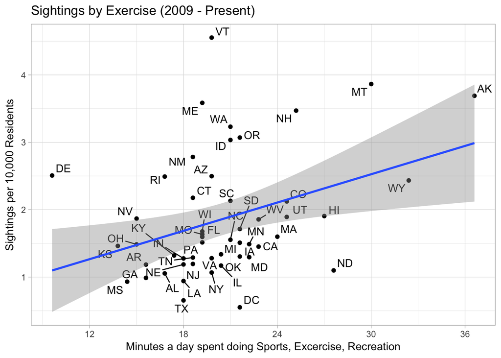

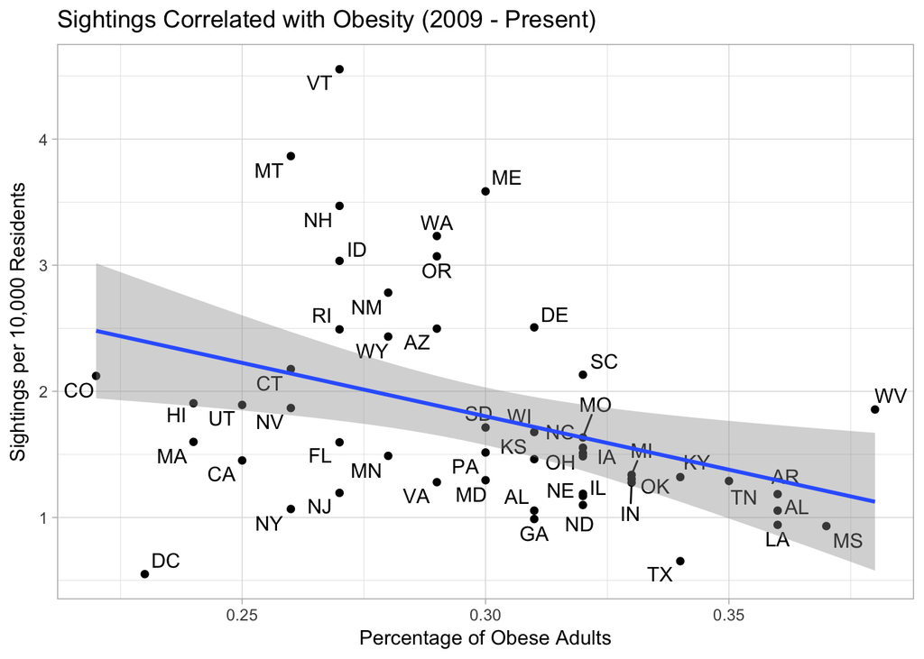

Given our results from our analysis, we did not find the relationships between the features in our data that we had hoped. We find it most likely that the relationships found in this data are caused by terresterial forces such as making a website, local marketing, and the effects of alien portrayal in pop culture. After contacting Dr. Davenport, the director of the NUFORC, he told us that work has been done that has found the relationships we tried to find, but it required identifying incorrect sightings caused by missles. This could possibly be future work, but the trends that are seen in this project are clearly results of subjective human reporting.